# Ford GoBike System

## Exploratory Data Analysis - by Donia Djerbi

## Introduction

> This data set includes informations about individual rides made in a bike-sharing system covering the greater San Francisco Bay area for the periode of February 2019. The purpose of the analysis is to answer the following questions:

### Questions for Analysis

> 01 - At what hour, day and which station have the highest number of bicycle hires?\ 02 - What type of users take more trips? and what gender as well?\ 03 - Does the age affect the number of trips.\ 04 - Does sharing the bike for all the trip affect the trip duration?\ 05 - What is the average trip duration and distance?

## Preliminary Wrangling

```python
# import all packages and set plots to be embedded inline
import numpy as np
import pandas as pd
import matplotlib.pyplot as plt
import seaborn as sb
sb.set_theme()
import plotly.express as px
import statistics


# Import library and module to calculate the distance
import geopy.distance
from geopy.distance import geodesic

%matplotlib inline
```

```python
# load in the dataset into a pandas dataframe, print statistics
bike = pd.read_csv('201902-fordgobike-tripdata.csv')
```

```python
bike.info()
```

```
<class 'pandas.core.frame.DataFrame'>
RangeIndex: 183412 entries, 0 to 183411
Data columns (total 16 columns):
 #   Column                   Non-Null Count   Dtype
---  ------                   --------------   -----
 0   duration_sec             183412 non-null  int64
 1   start_time               183412 non-null  object
 2   end_time                 183412 non-null  object
 3   start_station_id         183215 non-null  float64
 4   start_station_name       183215 non-null  object
 5   start_station_latitude   183412 non-null  float64
 6   start_station_longitude  183412 non-null  float64
 7   end_station_id           183215 non-null  float64
 8   end_station_name         183215 non-null  object
 9   end_station_latitude     183412 non-null  float64
 10  end_station_longitude    183412 non-null  float64
 11  bike_id                  183412 non-null  int64
 12  user_type                183412 non-null  object
 13  member_birth_year        175147 non-null  float64
 14  member_gender            175147 non-null  object
 15  bike_share_for_all_trip  183412 non-null  object
dtypes: float64(7), int64(2), object(7)
memory usage: 22.4+ MB
```

```python
bike.member_birth_year.isnull().sum()
```

```
8265
```

```python
bike.member_birth_year.describe()
```

```
count    175147.000000
mean       1984.806437
std          10.116689
min        1878.000000
25%        1980.000000
50%        1987.000000
75%        1992.000000
max        2001.000000
Name: member_birth_year, dtype: float64
```

```python
# Convert the member birth year to int and fill the nan values with the mean birth year
bike['member_birth_year'] = pd.to_numeric(bike['member_birth_year'], errors='coerce').fillna(1984).astype(int)
```

```python
# Make copy of original data
df = bike.copy()
```

```python
# Convert start_time and end_time to datetime
df['start_time'] = pd.to_datetime(df['start_time'])
df['end_time'] = pd.to_datetime(df['end_time'])
```

```python
# Find correspanding start hour and day of the week
df['start_hour'] = df.start_time.dt.hour
df['start_dayofweek'] = df.start_time.dt.day_name()
df['Year'] = df.start_time.dt.year
```

```python
df['Date'] = df.start_time.dt.date
df['Date'] = pd.to_datetime(df['Date'])
```

```python
# Find correspanding end hour and day of the week
df['end_hour'] = df.end_time.dt.hour
df['end_dayofweek'] = df.end_time.dt.day_name()
```

```python
# Define the order of days
cat_type = pd.api.types.CategoricalDtype(categories=['Monday', 'Tuesday', 'Wednesday', 'Thursday', 'Friday', 'Saturday', 'Sunday'], ordered=True)
df['start_dayofweek']  = df['start_dayofweek'].astype(cat_type)
df['end_dayofweek']  = df['end_dayofweek'].astype(cat_type)
```

```python
# Find the age of the users
df['Age'] = 2019 - df['member_birth_year']
```

```python
df.describe().Age
```

```
count    183412.000000
mean         34.229903
std           9.887534
min          18.000000
25%          27.000000
50%          32.000000
75%          38.000000
max         141.000000
Name: Age, dtype: float64
```

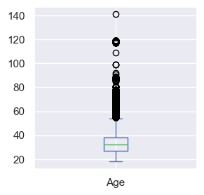

```python
df['Age'].plot(kind = 'box', figsize = (3,3));
```

```python
# Drop rows with the age equal or more then 80
df.drop(df[(df['Age'] >= 80) ].index, inplace=True)
```

```python
# Convert member_gender and user_type to category data type
df['member_gender'] = df['member_gender'].astype('category')
df['user_type'] = df['user_type'].astype('category')
df['bike_share_for_all_trip'] = df['bike_share_for_all_trip'].astype('category')
```

```python
# Get the ride duration per minute
df['duration_min'] = df['duration_sec']/ 60

# Get the ride duration per hour
df['duration_hour'] = df['duration_min']/60
```

```python
# Convert bike_id to str type
df['bike_id'] = df['bike_id'].astype(str)
```

Lets calculate the distance between the start station and the end station, which could means also the travelled distance.

```python
def calc_distance(x):
    start = (x.start_station_latitude, x.start_station_longitude)
    end = (x.end_station_latitude, x.end_station_longitude)
    return geopy.distance.geodesic(start, end ).km
df['distance'] = df.apply(calc_distance, axis = 1)
```

```python
# Reorder columns and keep only the necessary ones
df = df[['duration_hour','duration_min', 'distance','Date', 'start_dayofweek','start_hour','end_dayofweek','end_hour','start_station_name','end_station_name','user_type','member_gender','bike_share_for_all_trip','Age','bike_id']]
```

```python
df.info()
```

```
<class 'pandas.core.frame.DataFrame'>
Int64Index: 183209 entries, 0 to 183411
Data columns (total 15 columns):
 #   Column                   Non-Null Count   Dtype
---  ------                   --------------   -----
 0   duration_hour            183209 non-null  float64
 1   duration_min             183209 non-null  float64
 2   distance                 183209 non-null  float64
 3   Date                     183209 non-null  datetime64[ns]
 4   start_dayofweek          183209 non-null  category
 5   start_hour               183209 non-null  int64
 6   end_dayofweek            183209 non-null  category
 7   end_hour                 183209 non-null  int64
 8   start_station_name       183012 non-null  object
 9   end_station_name         183012 non-null  object
 10  user_type                183209 non-null  category
 11  member_gender            174944 non-null  category
 12  bike_share_for_all_trip  183209 non-null  category
 13  Age                      183209 non-null  int32
 14  bike_id                  183209 non-null  object
dtypes: category(5), datetime64[ns](1), float64(3), int32(1), int64(2), object(3)
memory usage: 15.6+ MB
```

```python
df.describe()
```

|  | duration_hour | duration_min | distance | start_hour | end_hour | Age |
| --- | --- | --- | --- | --- | --- | --- |
| count | 183209.000000 | 183209.000000 | 183209.000000 | 183209.000000 | 183209.000000 | 183209.000000 |
| mean | 0.201774 | 12.106449 | 1.690954 | 13.458367 | 13.614779 | 34.158851 |
| std | 0.498697 | 29.921792 | 1.096885 | 4.726196 | 4.740863 | 9.646045 |
| min | 0.016944 | 1.016667 | 0.000000 | 0.000000 | 0.000000 | 18.000000 |
| 25% | 0.090278 | 5.416667 | 0.909777 | 9.000000 | 9.000000 | 27.000000 |
| 50% | 0.142778 | 8.566667 | 1.431053 | 14.000000 | 14.000000 | 32.000000 |
| 75% | 0.221111 | 13.266667 | 2.227114 | 17.000000 | 18.000000 | 38.000000 |
| max | 23.734444 | 1424.066667 | 69.465977 | 23.000000 | 23.000000 | 78.000000 |

```python
print(f"Number of unique start stations: {df['start_station_name'].nunique()}")
print(f"Number of unique end stations: {df['end_station_name'].nunique()}")
```

```
Number of unique start stations: 329
Number of unique end stations: 329
```

```python
print(f"Type of users: {df['user_type'].unique()}")
print(f"Member gender: {df['member_gender'].unique()}")
```

```
Type of users: ['Customer', 'Subscriber']
Categories (2, object): ['Customer', 'Subscriber']
Member gender: ['Male', NaN, 'Other', 'Female']
Categories (3, object): ['Female', 'Male', 'Other']
```

### What is/are the main feature(s) of interest in your dataset?

> I am interested in figuring out what are the most important features that have an impact on the choice of the start station.

### What features in the dataset do you think will help support your investigation into your feature(s) of interest?

> I expect that the variables of the ride starting data as well as the user's type could have a strong effect.

## Univariate Exploration

```python
# Create a function to plot histograms
def hist_func(S,A, Title):
    binsize = S
    bins = np.arange(df[A].min(), df[A].max()+binsize, binsize)
    plt.figure(figsize = (5,4))
    fig = sb.histplot(data=df, x = A, bins=bins, color='#15616d')
    plt.xlabel(A)
    title = plt.title(Title)
    plt.show()
    return fig
```

I will start by looking at the main feature: the trip duration

### Rides duration's distribution in minutes

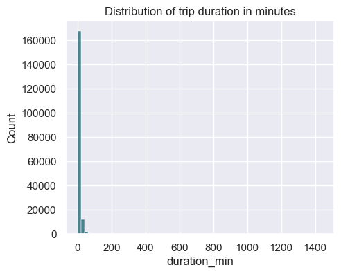

```python
hist_func(20, 'duration_min', 'Distribution of trip duration in minutes');
```

Let's take a closer look and plot the trip duration on a log scale

```python
m = statistics.mean(df['duration_min'] )
std = statistics.stdev(df['duration_min'] )
median = statistics.median(df['duration_min'] )
print(f"Mean =  {m}")
print(f"Standard deviation =  {std}")
print(f"Median =  {median}")
```

```
Mean =  12.106449373848083
Standard deviation =  29.9217923073707
Median =  8.566666666666666
```

```python
#Create a function to plot histograms on a log scale
def log_function(data, B, A, Title):
    log_binsize = 0.1
    bins = 10 ** np.arange(np.log10(df[A].min()), np.log10(df[A].max())+log_binsize, log_binsize)

    plt.figure(figsize=[5, 5])
    fig = plt.hist(data = data , x = A, bins = bins, edgecolor='k')
    plt.axvline(m, color ='r', linestyle='dashed')
    plt.axvline(median, color ='g', linestyle='dashed')
    plt.axvline(m+std, color ='y', linestyle='dashed')
    plt.axvline(m-std, color ='y', linestyle='dashed')
    plt.xscale('log')
    plt.xlabel(Title)
    plt.ylabel('Counts')
    plt.show()
    return fig
```

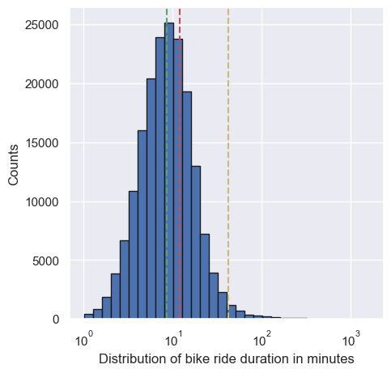

```python
log_function(df, 0.1, 'duration_min', 'Distribution of bike ride duration in minutes');
```

We can see that the average duration of bike rides is 12 minutes however the median duration is 8 minutes. The hystogram presents an asymmetric normal distribution with a standard deviation of 29.9 wich means that the data is spread.\ The mean is higher than the median, so, it is a right-skewed data. Now, I want to find out the outliers.

```python
from scipy.stats import iqr

# Calculate the interquartile range IQR of the ride duration per minutes then calculate the lower and the upper thresholds
iqr = iqr(df['duration_min'])
lower_threshold = np.quantile(df['duration_min'], 0.25) - 1.5 * iqr
upper_threshold = np.quantile(df['duration_min'], 0.75) + 1.5 * iqr

# Subset the data frame to find rides with duration above and below thresholds
outliers = df[(df['duration_min'] < lower_threshold) | (df['duration_min'] > upper_threshold)]
```

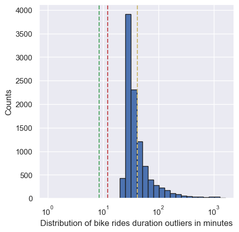

```python
log_function(outliers, 0.5,'duration_min', 'Distribution of bike rides duration outliers in minutes' );
```

All the ride duration outliers are above 25 minutes and some of them go even until 1000 min.

### Rides distance's distribution in km

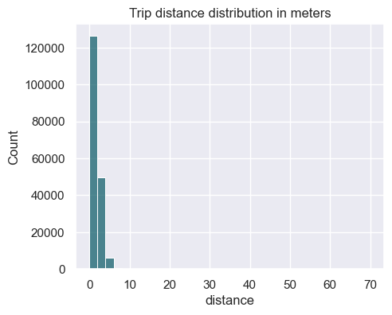

```python
hist_func(2, 'distance', 'Trip distance distribution in meters');
```

```python
df.distance.describe()
```

```
count    183209.000000
mean          1.690954
std           1.096885
min           0.000000
25%           0.909777
50%           1.431053
75%           2.227114
max          69.465977
Name: distance, dtype: float64
```

```python
df[df['distance'] == 0]
```

|  | duration_hour | duration_min | distance | Date | start_dayofweek | start_hour | end_dayofweek | end_hour | start_station_name | end_station_name | user_type | member_gender | bike_share_for_all_trip | Age | bike_id |
| --- | --- | --- | --- | --- | --- | --- | --- | --- | --- | --- | --- | --- | --- | --- | --- |
| 19 | 0.242778 | 14.566667 | 0.0 | 2019-02-28 | Thursday | 23 | Thursday | 23 | Telegraph Ave at 23rd St | Telegraph Ave at 23rd St | Customer | Male | No | 41 | 5629 |
| 27 | 0.113333 | 6.800000 | 0.0 | 2019-02-28 | Thursday | 23 | Thursday | 23 | Folsom St at 9th St | Folsom St at 9th St | Subscriber | Male | No | 37 | 5410 |
| 34 | 0.130833 | 7.850000 | 0.0 | 2019-02-28 | Thursday | 23 | Thursday | 23 | Valencia St at 22nd St | Valencia St at 22nd St | Subscriber | Male | No | 27 | 5559 |
| 53 | 0.949444 | 56.966667 | 0.0 | 2019-02-28 | Thursday | 22 | Thursday | 23 | Davis St at Jackson St | Davis St at Jackson St | Customer | NaN | No | 35 | 319 |
| 55 | 0.966111 | 57.966667 | 0.0 | 2019-02-28 | Thursday | 22 | Thursday | 23 | Davis St at Jackson St | Davis St at Jackson St | Subscriber | Male | No | 24 | 1846 |
| ... | ... | ... | ... | ... | ... | ... | ... | ... | ... | ... | ... | ... | ... | ... | ... |
| 183317 | 0.410000 | 24.600000 | 0.0 | 2019-02-01 | Friday | 2 | Friday | 3 | Hubbell St at 16th St | Hubbell St at 16th St | Subscriber | Male | No | 52 | 5224 |
| 183318 | 0.243611 | 14.616667 | 0.0 | 2019-02-01 | Friday | 2 | Friday | 3 | Woolsey St at Sacramento St | Woolsey St at Sacramento St | Subscriber | Male | No | 32 | 4913 |
| 183326 | 1.586944 | 95.216667 | 0.0 | 2019-02-01 | Friday | 1 | Friday | 2 | Raymond Kimbell Playground | Raymond Kimbell Playground | Subscriber | Male | No | 47 | 5366 |
| 183350 | 0.242778 | 14.566667 | 0.0 | 2019-02-01 | Friday | 1 | Friday | 1 | Haste St at College Ave | Haste St at College Ave | Subscriber | Male | Yes | 24 | 3232 |
| 183380 | 0.261944 | 15.716667 | 0.0 | 2019-02-01 | Friday | 0 | Friday | 0 | Raymond Kimbell Playground | Raymond Kimbell Playground | Subscriber | Male | No | 47 | 5343 |

3878 rows × 15 columns

```python
# Copy of the dataframe with distance more than zero
df.drop(df.loc[df.distance == 0, 'distance' ], inplace = True)
```

```python
df[df['distance'] == 0]
```

|  | duration_hour | duration_min | distance | Date | start_dayofweek | start_hour | end_dayofweek | end_hour | start_station_name | end_station_name | user_type | member_gender | bike_share_for_all_trip | Age | bike_id |
| --- | --- | --- | --- | --- | --- | --- | --- | --- | --- | --- | --- | --- | --- | --- | --- |
| 19 | 0.242778 | 14.566667 | 0.0 | 2019-02-28 | Thursday | 23 | Thursday | 23 | Telegraph Ave at 23rd St | Telegraph Ave at 23rd St | Customer | Male | No | 41 | 5629 |
| 27 | 0.113333 | 6.800000 | 0.0 | 2019-02-28 | Thursday | 23 | Thursday | 23 | Folsom St at 9th St | Folsom St at 9th St | Subscriber | Male | No | 37 | 5410 |
| 34 | 0.130833 | 7.850000 | 0.0 | 2019-02-28 | Thursday | 23 | Thursday | 23 | Valencia St at 22nd St | Valencia St at 22nd St | Subscriber | Male | No | 27 | 5559 |
| 53 | 0.949444 | 56.966667 | 0.0 | 2019-02-28 | Thursday | 22 | Thursday | 23 | Davis St at Jackson St | Davis St at Jackson St | Customer | NaN | No | 35 | 319 |
| 55 | 0.966111 | 57.966667 | 0.0 | 2019-02-28 | Thursday | 22 | Thursday | 23 | Davis St at Jackson St | Davis St at Jackson St | Subscriber | Male | No | 24 | 1846 |
| ... | ... | ... | ... | ... | ... | ... | ... | ... | ... | ... | ... | ... | ... | ... | ... |
| 183317 | 0.410000 | 24.600000 | 0.0 | 2019-02-01 | Friday | 2 | Friday | 3 | Hubbell St at 16th St | Hubbell St at 16th St | Subscriber | Male | No | 52 | 5224 |
| 183318 | 0.243611 | 14.616667 | 0.0 | 2019-02-01 | Friday | 2 | Friday | 3 | Woolsey St at Sacramento St | Woolsey St at Sacramento St | Subscriber | Male | No | 32 | 4913 |
| 183326 | 1.586944 | 95.216667 | 0.0 | 2019-02-01 | Friday | 1 | Friday | 2 | Raymond Kimbell Playground | Raymond Kimbell Playground | Subscriber | Male | No | 47 | 5366 |
| 183350 | 0.242778 | 14.566667 | 0.0 | 2019-02-01 | Friday | 1 | Friday | 1 | Haste St at College Ave | Haste St at College Ave | Subscriber | Male | Yes | 24 | 3232 |
| 183380 | 0.261944 | 15.716667 | 0.0 | 2019-02-01 | Friday | 0 | Friday | 0 | Raymond Kimbell Playground | Raymond Kimbell Playground | Subscriber | Male | No | 47 | 5343 |

3878 rows × 15 columns

Now, I want to have a look on distance outliers.

```python
from scipy.stats import iqr
iqr2 = iqr (df['distance'])
lower_threshold2 = np.quantile(df['distance'], 0.25) - 1.5 * iqr2
upper_threshold2 = np.quantile(df['distance'], 0.75) + 1.5 * iqr2
```

```python
# Subset the data frame to find rides with duration above and below thresholds
distance_outliers = df[(df['distance'] < lower_threshold) | (df['distance'] > upper_threshold)]
distance_outliers
```

|  | duration_hour | duration_min | distance | Date | start_dayofweek | start_hour | end_dayofweek | end_hour | start_station_name | end_station_name | user_type | member_gender | bike_share_for_all_trip | Age | bike_id |
| --- | --- | --- | --- | --- | --- | --- | --- | --- | --- | --- | --- | --- | --- | --- | --- |
| 112038 | 1.929167 | 115.75 | 69.465977 | 2019-02-12 | Tuesday | 14 | Tuesday | 16 | Montgomery St BART Station (Market St at 2nd St) | Palm St at Willow St | Subscriber | Female | No | 34 | 4780 |

```python
df.drop([112038], inplace = True)
```

```python
#df.drop(df.loc[df.distance == 69.465977, 'distance' ], inplace = True)
```

```python
#df.loc[df['distance'] == 69.465977]
```

```python
# Find the mean, median and standard deviation
m_distance = statistics.mean(df['distance'] )
std_distance = statistics.stdev(df['distance'] )
median_distance = statistics.median(df['distance'] )
print(f"Mean =  {m_distance}")
print(f"Standard deviation =  {std_distance}")
print(f"Median =  {median_distance}")
print(np.quantile(df['distance'], np.linspace(0, 1, 5)))
```

```
Mean =  1.6905905404623673
Standard deviation =  1.085398859799622
Median =  1.4310527427643085
[ 0.          0.90977725  1.43105274  2.22711357 15.71115564]
```

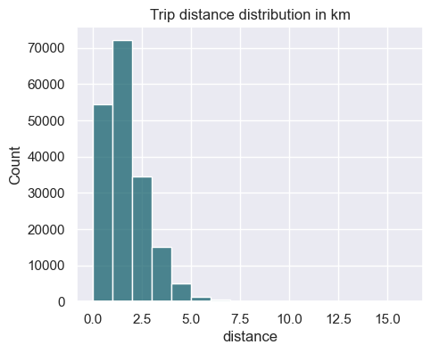

```python
hist_func(1, 'distance', 'Trip distance distribution in km');
```

### User's age distribution

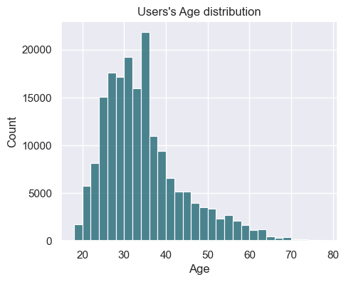

```python
hist_func(2, 'Age', "Users's Age distribution");
```

```python
df.Age.describe()
```

```
count    183207.000000
mean         34.158848
std           9.646097
min          18.000000
25%          27.000000
50%          32.000000
75%          38.000000
max          78.000000
Name: Age, dtype: float64
```

> The histogram presents an asymetric and right-skewed distribution. Most of users's age is between 27 and 38. The data is spread with a standard deviation of 9.6 years.

### Start and end hours distribution

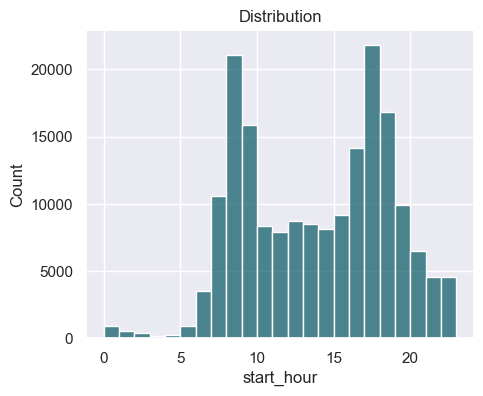

```python
hist_func(1, 'start_hour', 'Distribution');
```

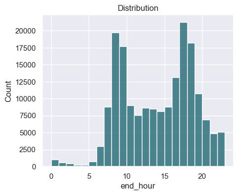

```python
hist_func(1, 'end_hour', 'Distribution');
```

> From the two above histograms, we can see two peaks one during the morning rush hours between 8 - 10 am and another during the evening rush hour between 5 - 7 pm. Lower bicycle rides during the night's hours and some hires the rest of the day.

```python
# Create a function to calculate and plot percentages
def percentage(A):
    base_color = sb.color_palette()[0]
    sb.countplot(data=df, x= A, color=base_color);


    # Recalculating the type_counts just to have clarity.
    type_counts = df[A].value_counts()

     # get the current tick locations and labels
    locs, labels = plt.xticks(rotation=90)

    # loop through each pair of locations and labels
    for loc, label in zip(locs, labels):

         # get the text property for the label to get the correct count
        count = type_counts[label.get_text()]
        sum_days = df[A].value_counts().sum()
        pct_string = '{:0.1f}%'.format(100*count/sum_days)

        # print the annotation just below the top of the bar
        plt.text(loc, count+2, pct_string, ha = 'center', color = 'black')
```

### Distribution of the categorial data types

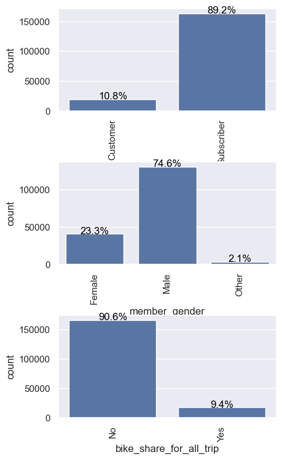

```python
# let's plot all three together to get an idea of each ordinal variable's distribution.
#plt.figure(figsize=[12, 6])
fig, ax = plt.subplots(nrows=3, figsize = [5,8])
fig.tight_layout(pad = 3)
plt.subplot(3,1,1)
percentage('user_type')

plt.subplot(3,1,2)
percentage('member_gender')

plt.subplot(3,1,3)
percentage('bike_share_for_all_trip')
```

> It can be seen from the bar charts above that the vast majority of bike users are subscribers and they dont share the bike for all the trip. There is more male users than females.

### Distribution of the start day and the end day of the bicycle rides

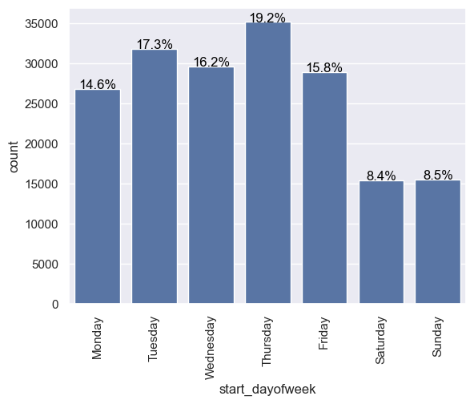

```python
percentage('start_dayofweek')
```

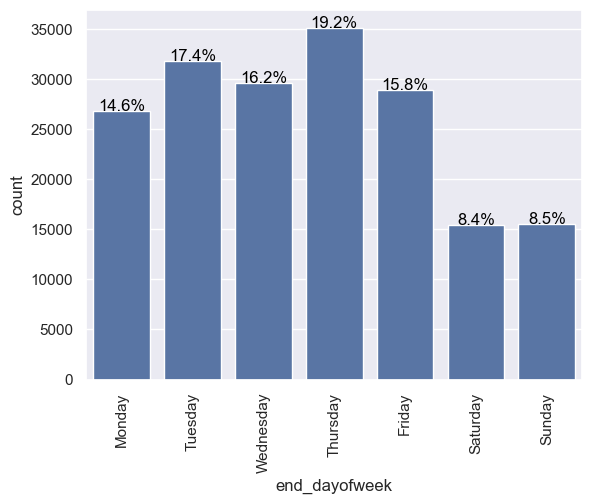

```python
percentage('end_dayofweek')
```

### Most common start and end stations

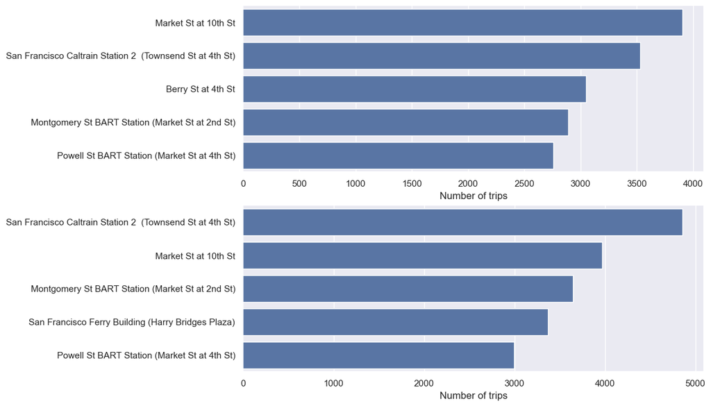

```python
base_color = sb.color_palette()[0]
plt.figure(figsize = [10,8])

# add frequency pokemon example
# Bar chart on left, the start days of the week

plt.subplot(2, 1, 1)
top_stations = df['start_station_name'].value_counts()[:5].index
sb.countplot(data = df, y ='start_station_name', color = base_color, order = top_stations)
plt.ylabel(None)
plt.xlabel('Number of trips')
# Bar chart on right, the end days of the week
plt.subplot(2, 1, 2)
type_order = df['end_station_name'].value_counts()[:5].index
sb.countplot(data = df, y ='end_station_name', color = base_color, order = type_order)
plt.ylabel(None)
plt.xlabel('Number of trips');
```

> The frequent start station is **Market St at 10th St** and the frequent end station is **San Francisco Caltrain Station 2**

### Discuss the distribution(s) of your variable(s) of interest. Were there any unusual points? Did you need to perform any transformations?

> The rides duration in minutes took on a large range of values, so I changed the x axis to a log axis. After transformation, the data presents an asymetric normal distribution.\ It seems that there is a data accuracy issue. there is no logic between ride duration ,the distance and the age. for the bivariate analysis, I will categorize the ages then, I will calculate the speed to have a clearer understanding.

## Bivariate Exploration

First of all, I want to have a closer look at the relation between duration and distance. First, I will create a column for ages category, then I will calculate the speed.

```python
# Create ages categories
bin_edges = [18, 25, 40, 50, 60, 78]
bin_names = ['18-25', '26-40', '41-50', '51-60', '60 or more']
df['Ages_category'] = pd.cut(df['Age'], bin_edges, labels=bin_names)
```

```python
# Create speed column
df['speed'] = df['distance']/df['duration_hour']
df.speed.describe()
```

```
count    183207.000000
mean         10.777320
std           3.947866
min           0.000000
25%           8.661268
50%          11.037080
75%          13.331473
max          28.709090
Name: speed, dtype: float64
```

```python
# Lookinf for outliers
from scipy.stats import iqr
iqrspeed = iqr (df['speed'])
lower_thresholdspeed = np.quantile(df['speed'], 0.25) - 1.5 * iqrspeed
upper_thresholdspeed = np.quantile(df['speed'], 0.75) + 1.5 * iqrspeed

# Subset the data frame to find rides with duration above and below thresholds
speed_outliers = df[(df['speed'] < lower_thresholdspeed) | (df['speed'] > upper_thresholdspeed)]
```

```python
speed_outliers.speed.describe()
```

```
count    7360.000000
mean        2.726065
std         6.677953
min         0.000000
25%         0.000000
50%         0.000000
75%         1.113914
max        28.709090
Name: speed, dtype: float64
```

```python
speed_outliers.groupby('Ages_category')['speed'].mean()
```

```
Ages_category
18-25         2.653732
26-40         2.999266
41-50         2.643367
51-60         1.565408
60 or more    0.865214
Name: speed, dtype: float64
```

```python
df.query('speed >= 1.93 & Age >= 60')
```

|  | duration_hour | duration_min | distance | Date | start_dayofweek | start_hour | end_dayofweek | end_hour | start_station_name | end_station_name | user_type | member_gender | bike_share_for_all_trip | Age | bike_id | Ages_category | speed |
| --- | --- | --- | --- | --- | --- | --- | --- | --- | --- | --- | --- | --- | --- | --- | --- | --- | --- |
| 5 | 0.498056 | 29.883333 | 3.328256 | 2019-02-28 | Thursday | 23 | Friday | 0 | 4th St at Mission Bay Blvd S | Broadway at Kearny | Subscriber | Male | No | 60 | 5200 | 51-60 | 6.682500 |
| 43 | 0.032222 | 1.933333 | 0.374629 | 2019-02-28 | Thursday | 23 | Thursday | 23 | 4th St at 16th St | 4th St at Mission Bay Blvd S | Subscriber | Male | No | 60 | 823 | 51-60 | 11.626406 |
| 67 | 0.189167 | 11.350000 | 2.571139 | 2019-02-28 | Thursday | 23 | Thursday | 23 | San Francisco Public Library (Grove St at Hyde... | Central Ave at Fell St | Subscriber | Male | No | 60 | 6333 | 51-60 | 13.591924 |
| 495 | 0.065278 | 3.916667 | 0.927997 | 2019-02-28 | Thursday | 21 | Thursday | 21 | Father Alfred E Boeddeker Park | Market St at 10th St | Subscriber | Male | No | 65 | 5202 | 60 or more | 14.216125 |
| 505 | 0.097778 | 5.866667 | 0.806959 | 2019-02-28 | Thursday | 21 | Thursday | 21 | Montgomery St BART Station (Market St at 2nd St) | Beale St at Harrison St | Subscriber | Male | No | 61 | 5108 | 60 or more | 8.252985 |
| ... | ... | ... | ... | ... | ... | ... | ... | ... | ... | ... | ... | ... | ... | ... | ... | ... | ... |
| 183289 | 0.213889 | 12.833333 | 2.235124 | 2019-02-01 | Friday | 5 | Friday | 5 | San Francisco Caltrain Station 2 (Townsend St... | Washington St at Kearny St | Subscriber | Male | No | 60 | 4960 | 51-60 | 10.449929 |
| 183296 | 0.127500 | 7.650000 | 1.130470 | 2019-02-01 | Friday | 5 | Friday | 5 | 4th St at 16th St | San Francisco Caltrain (Townsend St at 4th St) | Subscriber | Male | No | 60 | 3446 | 51-60 | 8.866429 |
| 183304 | 0.103611 | 6.216667 | 1.238314 | 2019-02-01 | Friday | 4 | Friday | 4 | 22nd St at Dolores St | Harrison St at 20th St | Subscriber | Male | No | 61 | 5427 | 60 or more | 11.951555 |
| 183305 | 0.027778 | 1.666667 | 0.229420 | 2019-02-01 | Friday | 4 | Friday | 4 | Townsend St at 5th St | San Francisco Caltrain Station 2 (Townsend St... | Subscriber | Male | No | 69 | 3138 | 60 or more | 8.259119 |
| 183385 | 0.111111 | 6.666667 | 0.773709 | 2019-02-01 | Friday | 0 | Friday | 0 | San Pablo Ave at MLK Jr Way | Webster St at 19th St | Subscriber | Male | Yes | 74 | 3487 | 60 or more | 6.963381 |

3702 rows × 17 columns

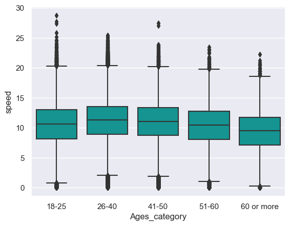

```python
sb.boxplot(data = df, x ='Ages_category', y = 'speed', color='#00A9A5');
```

```python
df.drop(df[(df['speed'] <= 1.931285) ].index, inplace=True)
```

```python
# Drop speed column as there is no need
df.drop('speed', axis = 1, inplace = True)
```

> Now, I want to look at the pairwise correlations present between features in the data

```python
numeric_vars = ['distance', 'duration_min','Age', 'start_hour', 'end_hour', 'Date']
categoric_vars = [ 'member_gender', 'bike_share_for_all_trip','user_type', 'Ages_category']
```

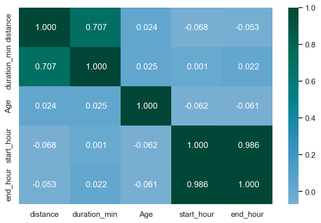

```python
plt.figure(figsize = [8, 5])
sb.heatmap(df[numeric_vars].corr(), annot = True, fmt = ' .3f', cmap = 'PuBuGn', center = 0)
plt.show()
```

### Is there a correlation between trip duration and the distance?

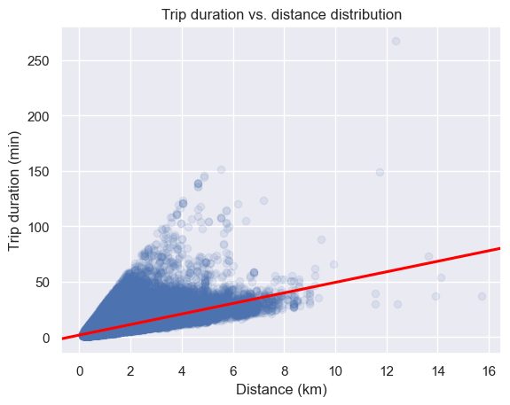

```python
# Scatter plot of distance vs. duration_min
sb.regplot(data=df, x='distance', y='duration_min', truncate=False, scatter_kws={'alpha':1/10},
           line_kws={"color": "red"})
plt.xlabel('Distance (km)')
plt.ylabel('Trip duration (min)')
plt.title('Trip duration vs. distance distribution');
```

As shown in the regression plot, there is a strong correlation with an r= 0.7, which indicates that the increase in one variable tends to increase the other one.

### Is there an effect of the user's age on the trip duration?

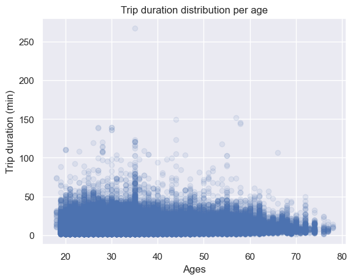

```python
plt.scatter(data=df, x='Age', y='duration_min', alpha = 1/10)
plt.xlabel('Ages')
plt.ylabel('Trip duration (min)')
plt.title('Trip duration distribution per age');
```

> There is not a strong correlation between age and trip duration, however the range of trip durations for all ages is between minutes and 50 minutes with outliers going until 250 min. However, for ages above 60, the trip duration decreases.

### What are the averages trip duration and distance for the top stations?

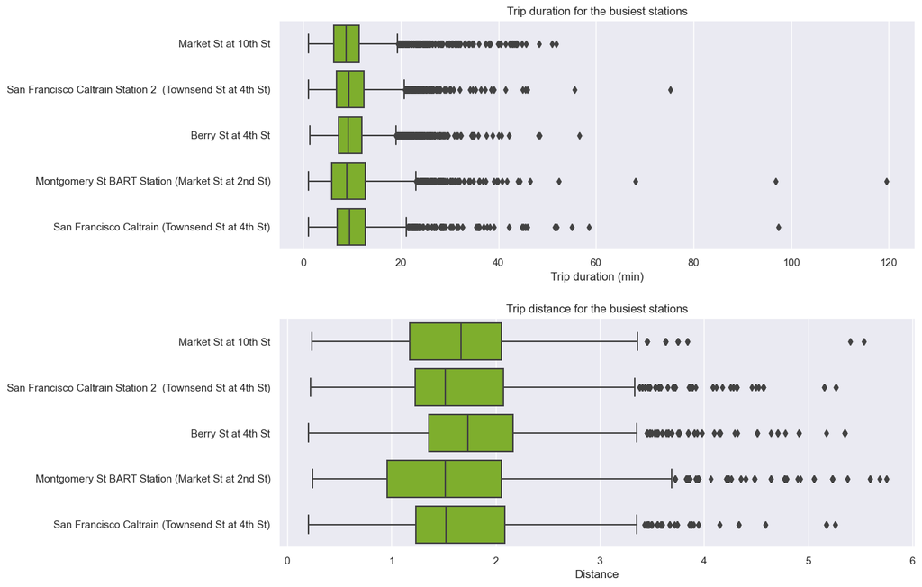

```python
Top_stations = df['start_station_name'].value_counts()[:5].index
fig, ax = plt.subplots(nrows = 2, figsize = [12,10])
plt.subplots_adjust(hspace = 0.3)
plt.subplot(2,1,1)
sb.boxplot(data = df, x='duration_min', y='start_station_name', order=Top_stations, color='#84C318')
ax[0].set_title('Trip duration for the busiest stations')
ax[0].set_yticklabels([],minor = True)
ax[0].set(ylabel = None)
ax[0].set(xlabel = 'Trip duration (min)')


plt.subplot(2,1,2)
sb.boxplot(data = df, x='distance', y='start_station_name', order=Top_stations, color='#84C318')
ax[1].set_title('Trip distance for the busiest stations')
ax[1].set_yticklabels([],minor = True)
ax[1].set(ylabel = None)
ax[1].set(xlabel = 'Distance');
```

> All the top 5 stations have the same trip duration average of about 10 min. However, regarding the average distance Berry St at 4th St has the max average distance followed by Market St at 10th St.

### What type of users have the highest number of bicycle hires?

```python
Top= pd.DataFrame(df.groupby(['Date','user_type']).count()['bike_id']).reset_index()
Top
```

|  | Date | user_type | bike_id |
| --- | --- | --- | --- |
| 0 | 2019-02-01 | Customer | 539 |
| 1 | 2019-02-01 | Subscriber | 5415 |
| 2 | 2019-02-02 | Customer | 419 |
| 3 | 2019-02-02 | Subscriber | 2599 |
| 4 | 2019-02-03 | Customer | 324 |
| 5 | 2019-02-03 | Subscriber | 2335 |
| 6 | 2019-02-04 | Customer | 415 |
| 7 | 2019-02-04 | Subscriber | 4918 |
| 8 | 2019-02-05 | Customer | 639 |
| 9 | 2019-02-05 | Subscriber | 7626 |
| 10 | 2019-02-06 | Customer | 662 |
| 11 | 2019-02-06 | Subscriber | 8153 |
| 12 | 2019-02-07 | Customer | 760 |
| 13 | 2019-02-07 | Subscriber | 8213 |
| 14 | 2019-02-08 | Customer | 536 |
| 15 | 2019-02-08 | Subscriber | 5644 |
| 16 | 2019-02-09 | Customer | 306 |
| 17 | 2019-02-09 | Subscriber | 2275 |
| 18 | 2019-02-10 | Customer | 508 |
| 19 | 2019-02-10 | Subscriber | 3133 |
| 20 | 2019-02-11 | Customer | 619 |
| 21 | 2019-02-11 | Subscriber | 7758 |
| 22 | 2019-02-12 | Customer | 649 |
| 23 | 2019-02-12 | Subscriber | 7623 |
| 24 | 2019-02-13 | Customer | 188 |
| 25 | 2019-02-13 | Subscriber | 2927 |
| 26 | 2019-02-14 | Customer | 561 |
| 27 | 2019-02-14 | Subscriber | 5856 |
| 28 | 2019-02-15 | Customer | 715 |
| 29 | 2019-02-15 | Subscriber | 6326 |
| 30 | 2019-02-16 | Customer | 597 |
| 31 | 2019-02-16 | Subscriber | 3091 |
| 32 | 2019-02-17 | Customer | 772 |
| 33 | 2019-02-17 | Subscriber | 2997 |
| 34 | 2019-02-18 | Customer | 801 |
| 35 | 2019-02-18 | Subscriber | 4418 |
| 36 | 2019-02-19 | Customer | 807 |
| 37 | 2019-02-19 | Subscriber | 8353 |
| 38 | 2019-02-20 | Customer | 892 |
| 39 | 2019-02-20 | Subscriber | 8482 |
| 40 | 2019-02-21 | Customer | 887 |
| 41 | 2019-02-21 | Subscriber | 8344 |
| 42 | 2019-02-22 | Customer | 955 |
| 43 | 2019-02-22 | Subscriber | 7882 |
| 44 | 2019-02-23 | Customer | 934 |
| 45 | 2019-02-23 | Subscriber | 4043 |
| 46 | 2019-02-24 | Customer | 678 |
| 47 | 2019-02-24 | Subscriber | 3488 |
| 48 | 2019-02-25 | Customer | 548 |
| 49 | 2019-02-25 | Subscriber | 6287 |
| 50 | 2019-02-26 | Customer | 332 |
| 51 | 2019-02-26 | Subscriber | 4907 |
| 52 | 2019-02-27 | Customer | 540 |
| 53 | 2019-02-27 | Subscriber | 6940 |
| 54 | 2019-02-28 | Customer | 891 |
| 55 | 2019-02-28 | Subscriber | 8607 |

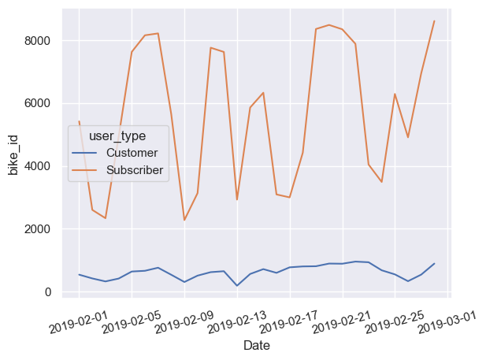

```python
sb.lineplot(data = Top, x ='Date', y = 'bike_id', hue = 'user_type')
plt.xticks(rotation = 15);
```

> As expected, Subscribers have the highest number of trips with ups and downs during the weekdays and weekends. Unlike subscribers, customers have a steady progress of rides's number across the month.

```python
# Create a function to plot violin plots
def violin_func(X , Y, Title, xlab):
    V = sb.violinplot(data=df, x= X, y=Y , color = '#00A9A5')
    V.set(xlabel = None)
    plt.ylabel('Start hours')
    plt.xlabel(xlab)
    plt.title(Title);
```

### What are the rush hours per day of the week?

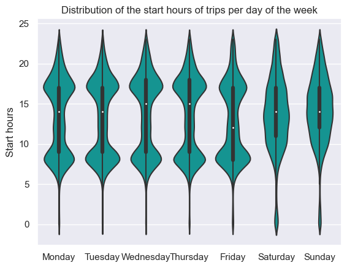

```python
violin_func('start_dayofweek','start_hour','Distribution of the start hours of trips per day of the week', None)
```

> As shown in the violin plot above, during weekdays the start hours of rides tend to be in the morning around 8 am or in the evening around 5 pm, which means at rush hours. However, during weekends, the bicycle hires tend to be all the day with an importante hires the afternoon.

### Distribution of start hours Vs. ages category

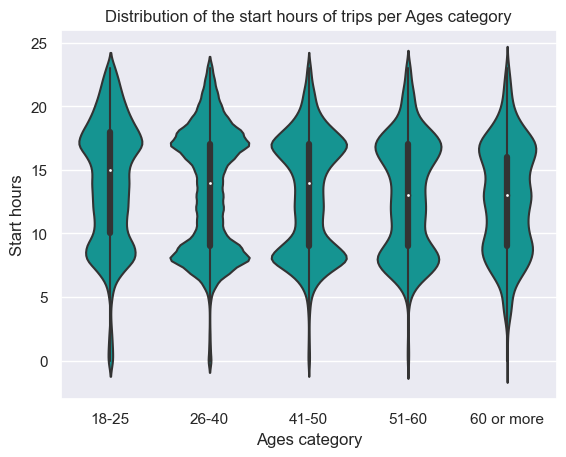

```python
violin_func('Ages_category','start_hour', 'Distribution of the start hours of trips per Ages category', 'Ages category' )
```

> It can be seen for ages below 60 years, that the bicycle hires are for the rush hours to go for work or to study. However for the riders above 60 years we can assume that the bicycle hires is equally distributed.

## How is the progress of bicycle hires for each top station across the month?

```python
Station= pd.DataFrame(df.groupby(['Date','start_station_name']).count()['bike_id'].sort_values(ascending = False).head(50)).reset_index()
```

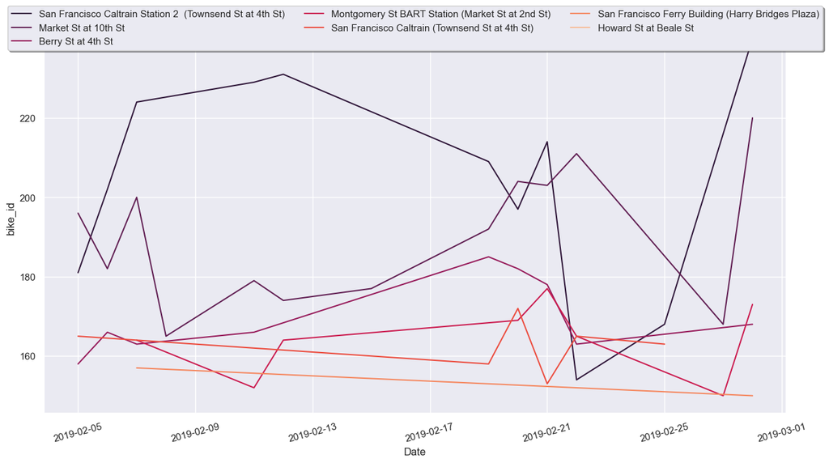

```python
plt.figure(figsize = [15, 8])
ax = sb.lineplot(data = Station, x ='Date', y = 'bike_id',
                 hue = 'start_station_name',
                 palette ='rocket',
                )
plt.xticks(rotation = 15)
ax.legend(loc='upper center', bbox_to_anchor=(0.5, 1.05),
          ncol=3, fancybox=True, shadow=True)

plt.show();
```

> San Fransisco Caltrain Station 2 and Market St have the highest number of trips with ups and downs across the month. However, Howard St have a steady number oh bicycle hires.

### Boxplots for categorical variables

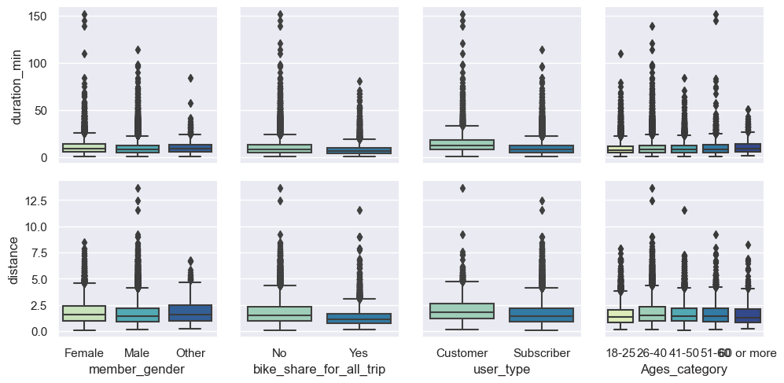

```python
samples = df.sample(frac =.25)
g = sb.PairGrid(data = samples, y_vars = ['duration_min', 'distance'], x_vars = categoric_vars, palette ='YlGnBu')
g.map(sb.boxplot)
```

### Categorial variables against the day of the week

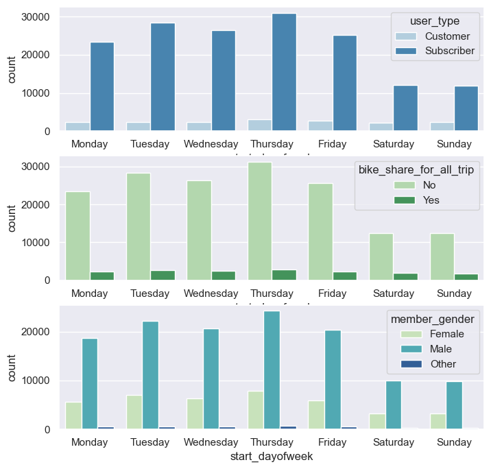

```python
plt.figure(figsize = [8, 8])

# subplot 1: start_dayofweek vs user_type
plt.subplot(3, 1, 1)
sb.countplot(data = df, x = 'start_dayofweek', hue = 'user_type', palette = 'Blues')

# subplot 2: start_dayofweek vs. bike_share_for_all_trip
plt.subplot(3, 1, 2)
sb.countplot(data = df, x = 'start_dayofweek', hue = 'bike_share_for_all_trip', palette = 'Greens')


# subplot 3: start_dayofweek vs. member_gender
plt.subplot(3, 1, 3)
sb.countplot(data = df, x = 'start_dayofweek', hue = 'member_gender', palette = 'YlGnBu')

plt.show()
```

> The three categorial variables represent a high number of rides at Thursdays as expected from the start day distribution. Additionally, with the plot above, we can see that the high majority of riders are subscribers, males and people who dont share the bike for all the trip.

### Talk about some of the relationships you observed in this part of the investigation. How did the feature(s) of interest vary with other features in the dataset?

> There is a relationship between the start hour and the day of the week. On the weekdays, the number of bicycle hires increases during the rush hours between 8 to 10 am and 5 to 7 pm. However, on weekends, there is no specific rush hour, bicycles are being hired all the day especially from 10am to 7pm.

### Did you observe any interesting relationships between the other features (not the main feature(s) of interest)?

> Interestingly, only subscribers have high number of trips.

## Multivariate Exploration

> For this part, I want to explore further more the effect of time and day on the station choice, as well as the effect of user type and gender in the trip distance and duration.

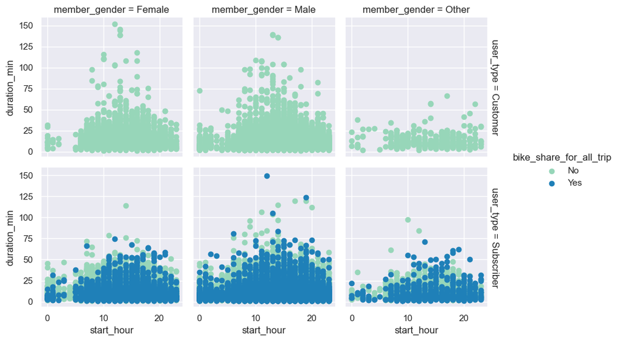

```python
g = sb.FacetGrid(data = df, col = 'member_gender', row = 'user_type',hue = 'bike_share_for_all_trip', palette ='YlGnBu', margin_titles = True)
g.map(plt.scatter, 'start_hour', 'duration_min').add_legend()
```

> These scatter plots show clearly the tendancy of customers to not share the bike for all the trip, unlike subscribers. We can see as well, that female customers tend to have longer trips . This can be clarified with the heat map below.

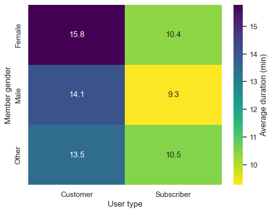

```python
cat_means = df.groupby(['user_type', 'member_gender']).mean()['duration_min']
cat_means = cat_means.reset_index(name = 'num_var2_avg')
cat_means = cat_means.pivot(index = 'member_gender', columns = 'user_type',
                            values = 'num_var2_avg')
sb.heatmap(cat_means, annot = True, fmt = '.1f',
           cbar_kws = {'label' : 'Average duration (min)'}, cmap='viridis_r')
plt.ylabel('Member gender')
plt.xlabel('User type');
```

> As expected, customer females have longer trips with an average of 15.8 minutes. Now, I want to explore the effect of the day and the hour on the choice of the station.

## At what time, what day and which station is the highest number of bicycle hires?

```python
rush_hour_perday_perstation = df.groupby(['start_station_name', 'start_dayofweek','start_hour'])['bike_id'].count()
rush_hour_perday_perstation = rush_hour_perday_perstation.reset_index(name = 'count')
```

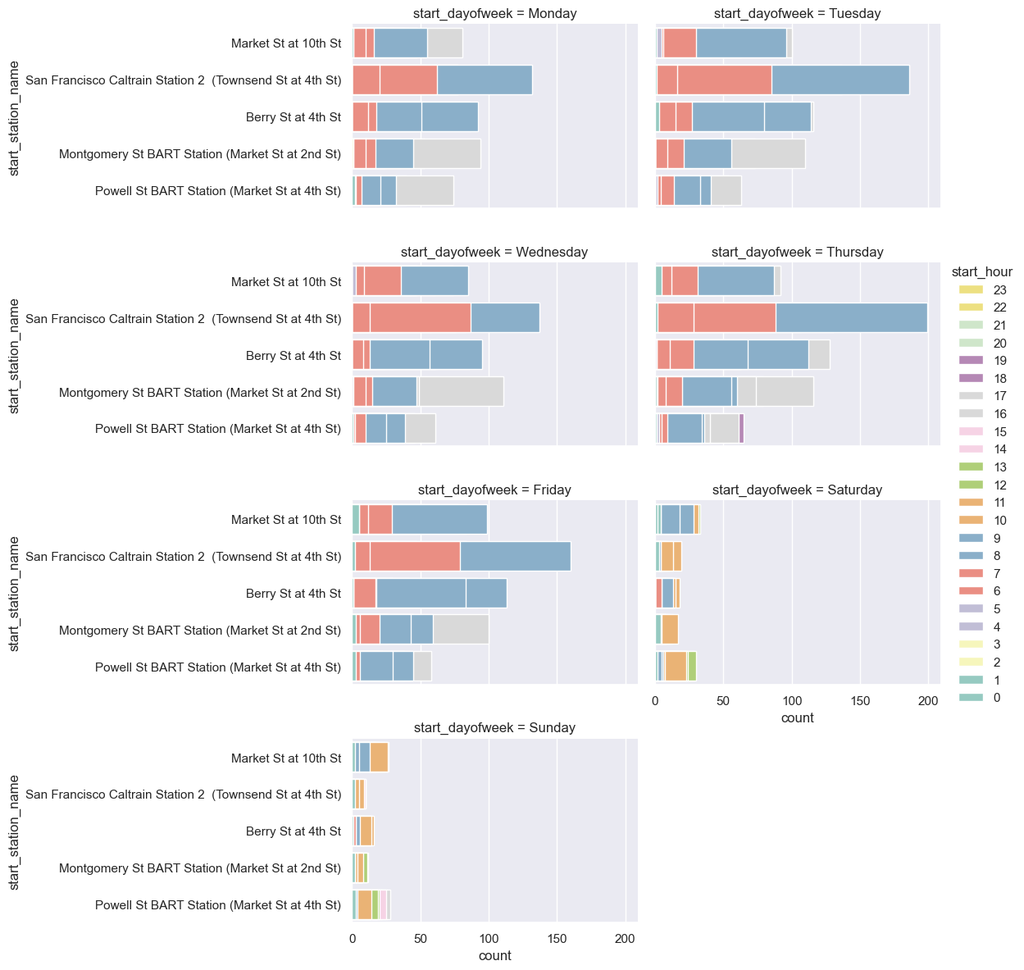

```python
times = df.start_hour.unique()
g = sb.FacetGrid(rush_hour_perday_perstation, col="start_dayofweek",
                 hue="start_hour",hue_order = times,
                   aspect=2, col_wrap=2, palette = 'Set3_r')
g.map(sb.barplot, 'count', 'start_station_name', order=top_stations ).add_legend();
```

> The figure above is devided into days of the week so, we can see for each day what station is the busiest and at what hour. At mondays for instance, San Fransisco Caltrain Station 2 is the station with the highest number of bicycle hires espacially between 6 and 9 am. Therefore, there should be enough bicycles.

### Talk about some of the relationships you observed in this part of the investigation. Were there features that strengthened each other in terms of looking at your feature(s) of interest?

> I extended my investigation of station choice against trip duration and distance in this section by looking at the impact of the start hour and the day of the week. The multivariate exploration here showed that there indeed is a relationship between theses features.

### Were there any interesting or surprising interactions between features?

> Surprisengly, Monday is not the active day, Thursday is. Interestingly, female customers have the highest average of trip duration. Customers do not share the bike for all the trip.